# QMP Differential Abundance Analysis Across Diagnosis Groups

### PCoA on BCD representing QMP species-level microbiota variation in the LCPM cohort (n = 589)

Each dot represents one sample, colored by assigned diagnosis group.

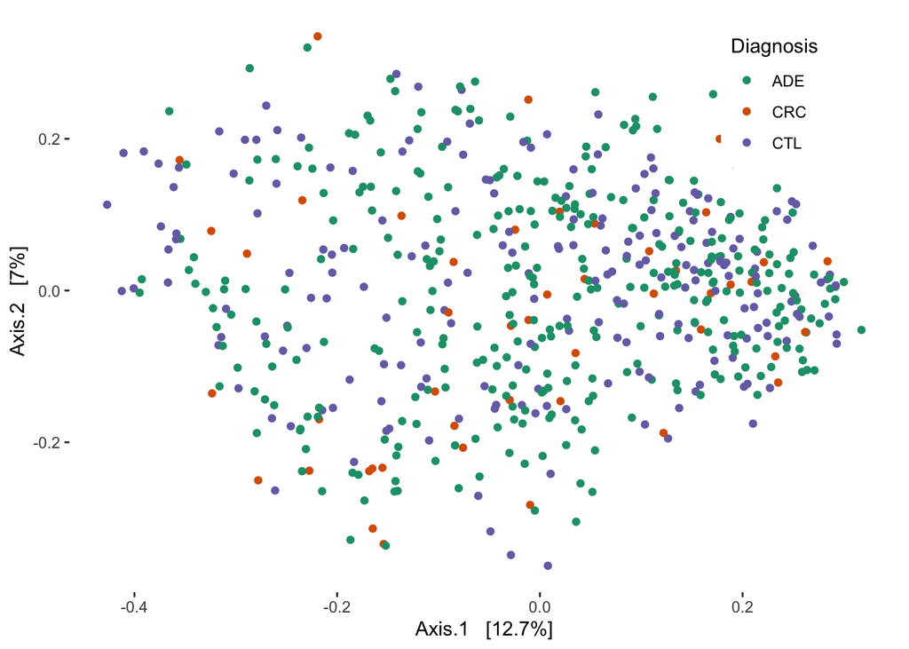

Cancer diagnosis group (CTL, ADE and CRC), as a covariate, was not associated with microbial variation (n = 589, univariate dbRDA)

```
##                     F          r2       adjr2 p.value  qval
## Diagnosis   1.2255444 0.004929953 0.001533809   0.093 0.186
## Colonoscopy 0.9563407 0.028760712 0.002918425   0.728 0.728
```

### Microbial biomarkers in CRC

Nine species were identified with differential absolute abundance across diagnosis groups (n = 589, KW test, adjusted P < 0.05)

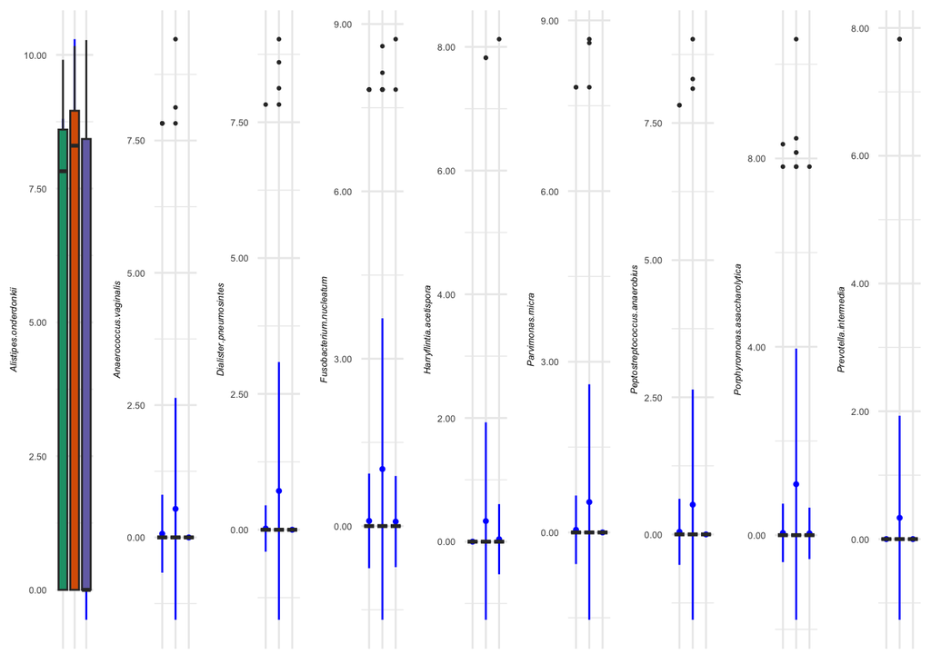

Kruskal-Wallis effect size analysis

| .y. | n | effsize | method | magnitude | Outcome |
| --- | --- | --- | --- | --- | --- |
| Peptostreptococcus.anaerobius | 589 | 0.0293946 | eta2[H] | small | Peptostreptococcus.anaerobius |
| Fusobacterium.nucleatum | 589 | 0.0468674 | eta2[H] | small | Fusobacterium.nucleatum |
| Parvimonas.micra | 589 | 0.0292350 | eta2[H] | small | Parvimonas.micra |
| Porphyromonas.asaccharolytica | 589 | 0.0699111 | eta2[H] | moderate | Porphyromonas.asaccharolytica |
| Dialister.pneumosintes | 589 | 0.0577238 | eta2[H] | small | Dialister.pneumosintes |
| Alistipes.onderdonkii | 589 | 0.0180274 | eta2[H] | small | Alistipes.onderdonkii |
| Prevotella.intermedia | 589 | 0.0360120 | eta2[H] | small | Prevotella.intermedia |
| Anaerococcus.vaginalis | 589 | 0.0232828 | eta2[H] | small | Anaerococcus.vaginalis |
| Harryflintia.acetispora | 589 | 0.0216153 | eta2[H] | small | Harryflintia.acetispora |

Dunn’s post hoc tests

.y.

group1

group2

n1

n2

statistic

p

p.adj

p.adj.signif

Peptostreptococcus.anaerobius

ADE

CRC

337

47

4.0666645

0.0000477

0.0000715

ADE.CRC

Peptostreptococcus.anaerobius

ADE

CTL

337

205

-0.7259797

0.4678512

0.4678512

ns

ADE.CTL

Peptostreptococcus.anaerobius

CRC

CTL

47

205

-4.3129161

0.0000161

0.0000483

CRC.CTL

Fusobacterium.nucleatum

ADE

CRC

337

47

5.2664485

0.0000001

0.0000004

ADE.CRC

Fusobacterium.nucleatum

ADE

CTL

337

205

-0.1509123

0.8800449

0.8800449

ns

ADE.CTL

Fusobacterium.nucleatum

CRC

CTL

47

205

-5.1530872

0.0000003

0.0000004

CRC.CTL

Parvimonas.micra

ADE

CRC

337

47

4.0551486

0.0000501

0.0000752

ADE.CRC

Parvimonas.micra

ADE

CTL

337

205

-0.7284575

0.4663336

0.4663336

ns

ADE.CTL

Parvimonas.micra

CRC

CTL

47

205

-4.3031859

0.0000168

0.0000505

CRC.CTL

Porphyromonas.asaccharolytica

ADE

CRC

337

47

6.3799315

0.0000000

0.0000000

ADE.CRC

Porphyromonas.asaccharolytica

ADE

CTL

337

205

-0.0968385

0.9228546

0.9228546

ns

ADE.CTL

Porphyromonas.asaccharolytica

CRC

CTL

47

205

-6.1955115

0.0000000

0.0000000

CRC.CTL

Dialister.pneumosintes

ADE

CRC

337

47

5.7566165

0.0000000

0.0000000

ADE.CRC

Dialister.pneumosintes

ADE

CTL

337

205

-0.3623704

0.7170752

0.7170752

ns

ADE.CTL

Dialister.pneumosintes

CRC

CTL

47

205

-5.7408245

0.0000000

0.0000000

CRC.CTL

Alistipes.onderdonkii

ADE

CRC

337

47

2.6495335

0.0080603

0.0120904

ADE.CRC

Alistipes.onderdonkii

ADE

CTL

337

205

-1.7293510

0.0837463

0.0837463

ns

ADE.CTL

Alistipes.onderdonkii

CRC

CTL

47

205

-3.4980645

0.0004686

0.0014059

CRC.CTL

Prevotella.intermedia

ADE

CRC

337

47

4.6939887

0.0000027

0.0000080

ADE.CRC

Prevotella.intermedia

ADE

CTL

337

205

0.0000000

1.0000000

1.0000000

ns

ADE.CTL

Prevotella.intermedia

CRC

CTL

47

205

-4.5192812

0.0000062

0.0000093

CRC.CTL

Anaerococcus.vaginalis

ADE

CRC

337

47

3.5232462

0.0004263

0.0006394

***

ADE.CRC

Anaerococcus.vaginalis

ADE

CTL

337

205

-0.9971993

0.3186678

0.3186678

ns

ADE.CTL

Anaerococcus.vaginalis

CRC

CTL

47

205

-3.9382673

0.0000821

0.0002462

***

CRC.CTL

Harryflintia.acetispora

ADE

CRC

337

47

3.8293727

0.0001285

0.0003854

***

ADE.CRC

Harryflintia.acetispora

ADE

CTL

337

205

0.7756142

0.4379768

0.4379768

ns

ADE.CTL

Harryflintia.acetispora

CRC

CTL

47

205

-3.2620509

0.0011061

0.0016591

CRC.CTL